# Causal inference

Last updated on 2025-11-24

```r
library(DiagrammeR) #grViz for causal diagrams
library(dagitty)    #for DAGs
library(ggdag)      #for DAGs
library(tidyverse)


### Set global options
options(digits = 3) # set the default number of digits to 3


### Rmd settings
knitr::opts_chunk$set(echo=TRUE, warning=FALSE, message=FALSE, fig.path="figures_md/causal_inference/")
```

# Introduction

In this module, we will examine a few case studies to understand the concept of causal inference. In particular, we focus on understanding (i) how to correctly estimate the causal effect of the predictor variable on the response variable, and (ii) whether we can infer the direction of causality from observational data.

To explore these questions, we will simulate data. The advantage of simulating data is that we know the true causal relationships between the variables. This allows us to compare the estimated causal effects with the true causal effects.

# Case study 1: A confounded relationship

In this case study, we will estimate the correct causal effect of a predictor variable on a response variable for the following DAG:

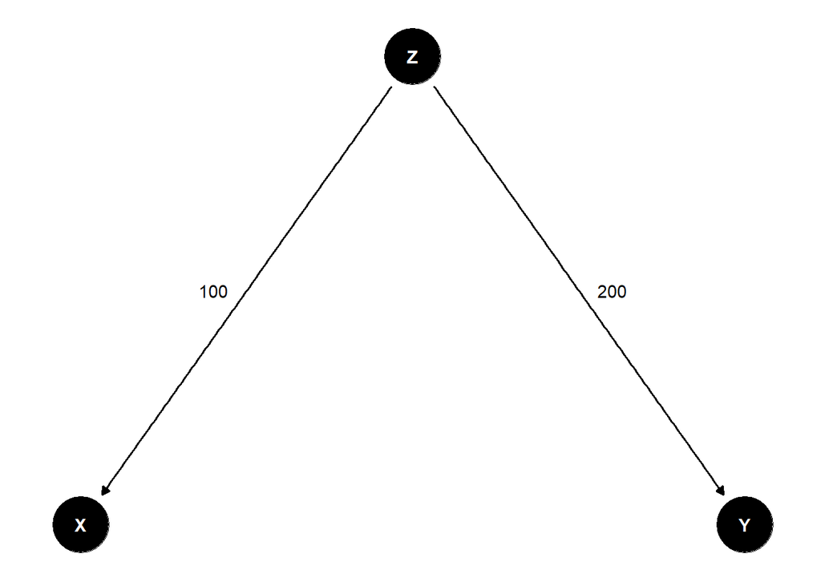

```r
dag <- dagitty('dag {
  X [pos="-1,0"]
  Y [pos="1,0"]
  Z [pos="0, 1"]
  Z -> X
  Z -> Y
}')

ggdag(dag) +
  theme_dag() +
  annotate("text", x = -0.6, y = 0.5, label = "100") +
  annotate("text", x = 0.6, y = 0.5, label = "200")
```

```r
adjustmentSets(dag, exposure = "X", outcome = "Y")
```

```
## { Z }
```

In this causal diagram, $Z$ is a confounder that affects both $X$ and $Y$. The true causal effect of $X$ on $Y$ is 0. To correctly estimate the causal effect of $X$ on $Y$, we need to adjust for the confounder $Z$. We will check cases where we do and do not adjust for the confounder $Z$ and estimate the causal effect of $X$ on $Y$.

Let’s simulate data and estimate the causal effect of $X$ on $Y$.

## Simulate data

```r
set.seed(123)

### set the effect sizes
beta_zx = 100
beta_zy = 200

### simulate data
n = 10000
z = rbinom(n, 1, 0.6)
x = beta_zx * z + rnorm(n, 500, 100)
y = beta_zy * z + rnorm(n, 500, 100)

data = data.frame(x = x, y = y, z = z)
data
```

| x | y | z |
| --- | --- | --- |
| 551 | 565 | 1 |
| 613 | 442 | 0 |
| 485 | 614 | 1 |
| 648 | 597 | 0 |
| 592 | 562 | 0 |
| 634 | 839 | 1 |
| 657 | 551 | 1 |
| 520 | 564 | 0 |
| 555 | 737 | 1 |
| 566 | 737 | 1 |

[output cut: 9990 more lines]

## Estimate the confounded causal effect

```r
m = lm(y ~ x, data = data)
summary(m)
```

```
##
## Call:
## lm(formula = y ~ x, data = data)
##
## Residuals:
##    Min     1Q Median     3Q    Max
## -476.1  -91.4    2.2   92.2  461.9
##
## Coefficients:
##             Estimate Std. Error t value Pr(>|t|)
## (Intercept) 395.7788     6.8014    58.2   <2e-16 ***
## x             0.3984     0.0119    33.5   <2e-16 ***
## ---
## Signif. codes:  0 '***' 0.001 '**' 0.01 '*' 0.05 '.' 0.1 ' ' 1
##
## Residual standard error: 133 on 9998 degrees of freedom
## Multiple R-squared:  0.101,  Adjusted R-squared:  0.101
## F-statistic: 1.12e+03 on 1 and 9998 DF,  p-value: <2e-16
```

This confounded model estimates a significant positive association between $X$ and $Y$, when we set the causal effect of $X$ on $Y$ and vice verse to be 0. This shows that the confounded model does not correctly estimate the causal effect of $X$ on $Y$.

## Estimate the causal effect of $Z$ on $X$ and $Y$

```r
mx = lm(x ~ z, data = data)
summary(mx)
```

```
##
## Call:
## lm(formula = x ~ z, data = data)
##
## Residuals:
##    Min     1Q Median     3Q    Max
## -383.7  -66.8   -0.5   69.7  383.9
##
## Coefficients:
##             Estimate Std. Error t value Pr(>|t|)
## (Intercept)   499.15       1.59   313.3   <2e-16 ***
## z             101.73       2.05    49.6   <2e-16 ***
## ---
## Signif. codes:  0 '***' 0.001 '**' 0.01 '*' 0.05 '.' 0.1 ' ' 1
##
## Residual standard error: 100 on 9998 degrees of freedom
## Multiple R-squared:  0.198,  Adjusted R-squared:  0.198
## F-statistic: 2.46e+03 on 1 and 9998 DF,  p-value: <2e-16
```

```r
my = lm(y ~ z, data = data)
summary(my)
```

```
##
## Call:
## lm(formula = y ~ z, data = data)
##
## Residuals:
##    Min     1Q Median     3Q    Max
## -352.7  -68.6   -0.7   67.6  434.2
##
## Coefficients:
##             Estimate Std. Error t value Pr(>|t|)
## (Intercept)   498.13       1.60   311.4   <2e-16 ***
## z             200.11       2.06    97.3   <2e-16 ***
## ---
## Signif. codes:  0 '***' 0.001 '**' 0.01 '*' 0.05 '.' 0.1 ' ' 1
##
## Residual standard error: 101 on 9998 degrees of freedom
## Multiple R-squared:  0.486,  Adjusted R-squared:  0.486
## F-statistic: 9.46e+03 on 1 and 9998 DF,  p-value: <2e-16
```

Both models correctly estimate the causal effect of $Z$ on $X$ and $Y$.

## Estimate the causal effect of $X$ on $Y$ adjusting for $Z$

```r
m = lm(y ~ x + z, data = data)
summary(m)
```

```
##
## Call:
## lm(formula = y ~ x + z, data = data)
##
## Residuals:
##    Min     1Q Median     3Q    Max
## -353.5  -68.6   -0.5   67.5  434.1
##
## Coefficients:
##             Estimate Std. Error t value Pr(>|t|)
## (Intercept) 492.3224     5.2603   93.59   <2e-16 ***
## x             0.0116     0.0100    1.16     0.25
## z           198.9303     2.2966   86.62   <2e-16 ***
## ---
## Signif. codes:  0 '***' 0.001 '**' 0.01 '*' 0.05 '.' 0.1 ' ' 1
##
## Residual standard error: 101 on 9997 degrees of freedom
## Multiple R-squared:  0.486,  Adjusted R-squared:  0.486
## F-statistic: 4.73e+03 on 2 and 9997 DF,  p-value: <2e-16
```

Now, the model with the minimum adjustment set correctly estimates the causal effect of $X$ on $Y$ to be near 0.

# Case study 2: Determining the direction of causality

In this case study, we will examine whether we can infer the direction of causality from observational data. We will consider the following DAG:

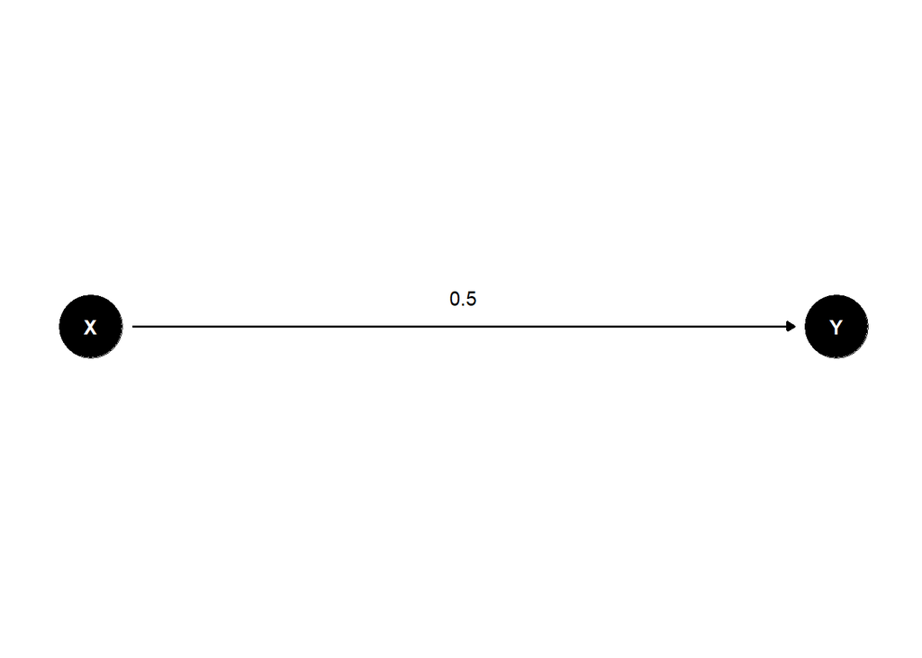

```r
dag <- dagitty('dag {
  X [pos="-1,0"]
  Y [pos="1,0"]
  X -> Y
}')

ggdag(dag) +
  theme_dag() +
  scale_y_continuous(limits = c(-1, 1)) +
  annotate("text", x = 0, y = 0.1, label = "0.5")
```

In this causal diagram, $X$ causes $Y$. We will estimate the causal effect of $X$ on $Y$ and $Y$ on $X$ and compare the results.

## Simulate data

```r
set.seed(123)

### set the effect sizes
beta_xy = 0.5

### simulate data
n = 10000
x = rnorm(n, 500, 100)
y = beta_xy * x + rnorm(n, 500, 100)

data = data.frame(x = x, y = y)
data
```

| x | y |
| --- | --- |
| 444 | 959 |
| 477 | 722 |
| 656 | 921 |
| 507 | 697 |
| 513 | 779 |
| 672 | 949 |
| 546 | 911 |
| 373 | 663 |
| 431 | 556 |
| 455 | 698 |

[output cut: 9990 more lines]

## Estimate the causal effect of $X$ on $Y$

```r
m = lm(y ~ x, data = data)
summary(m)
```

```
##
## Call:
## lm(formula = y ~ x, data = data)
##
## Residuals:
##    Min     1Q Median     3Q    Max
## -348.3  -66.9   -0.7   68.1  377.0
##
## Coefficients:
##             Estimate Std. Error t value Pr(>|t|)
## (Intercept)  496.071      5.112    97.0   <2e-16 ***
## x              0.506      0.010    50.5   <2e-16 ***
## ---
## Signif. codes:  0 '***' 0.001 '**' 0.01 '*' 0.05 '.' 0.1 ' ' 1
##
## Residual standard error: 100 on 9998 degrees of freedom
## Multiple R-squared:  0.203,  Adjusted R-squared:  0.203
## F-statistic: 2.55e+03 on 1 and 9998 DF,  p-value: <2e-16
```

The model correctly estimated the causal effect of $X$ on $Y$ to be 0.5.

Next, we will check the causal effect of $Y$ on $X$, which should be 0.

## Estimate the causal effect of $Y$ on $X$

```r
m = lm(x ~ y, data = data)
summary(m)
```

```
##
## Call:
## lm(formula = x ~ y, data = data)
##
## Residuals:
##    Min     1Q Median     3Q    Max
## -322.3  -59.9    0.3   60.3  334.9
##
## Coefficients:
##             Estimate Std. Error t value Pr(>|t|)
## (Intercept) 1.99e+02   6.02e+00    33.1   <2e-16 ***
## y           4.01e-01   7.95e-03    50.5   <2e-16 ***
## ---
## Signif. codes:  0 '***' 0.001 '**' 0.01 '*' 0.05 '.' 0.1 ' ' 1
##
## Residual standard error: 89.2 on 9998 degrees of freedom
## Multiple R-squared:  0.203,  Adjusted R-squared:  0.203
## F-statistic: 2.55e+03 on 1 and 9998 DF,  p-value: <2e-16
```

The model incorrectly estimated the causal effect of $Y$ on $X$ to be 0.4, when the true causal effect is 0. This shows that we cannot infer the direction of causality from observational data, at least with regression models.

We will also check if this holds when we adjust for the confounder $Z$.

# Case study 3: Determining the direction of causality with a confounder

In this case study, we will examine whether we can infer the direction of causality from observational data when there is a confounder. We will consider the following DAG:

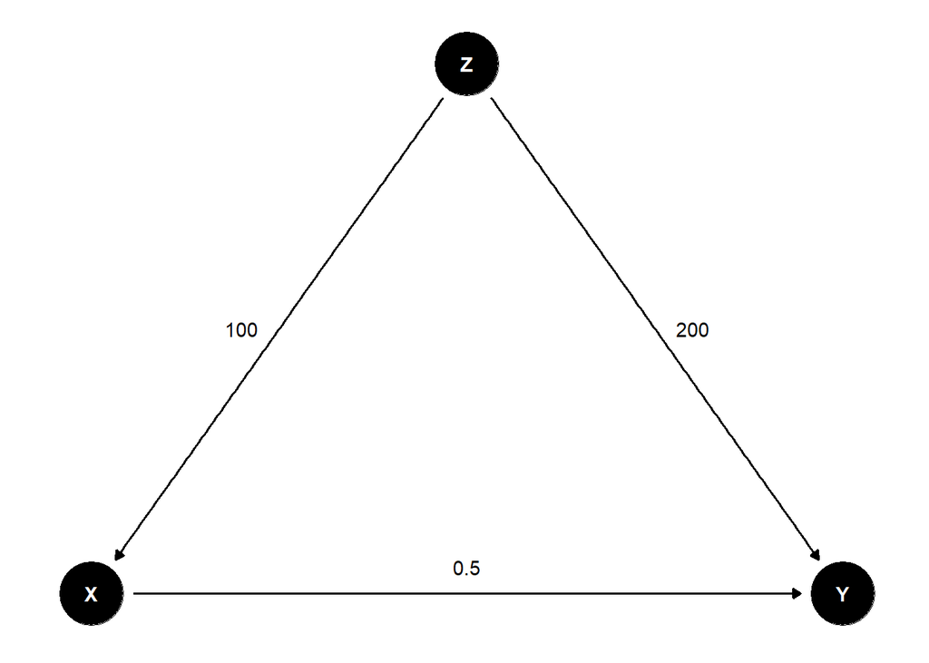

```r
dag <- dagitty('dag {
  X [pos="-1,0"]
  Y [pos="1,0"]
  Z [pos="0, 1"]
  X -> Y
  Z -> X
  Z -> Y
}')

ggdag(dag) +
  theme_dag() +
  annotate("text", x = -0.6, y = 0.5, label = "100") +
  annotate("text", x = 0.6, y = 0.5, label = "200") +
  annotate("text", x = 0, y = 0.05, label = "0.5")
```

## Simulate data

```r
set.seed(123)

### set the effect sizes
beta_zx = 100
beta_zy = 200
beta_xy = 0.5

### simulate data
n = 10000
z = rbinom(n, 1, 0.6)
x = beta_zx * z + rnorm(n, 500, 100)
y = beta_zy * z + beta_xy * x + rnorm(n, 500, 100)

data = data.frame(x = x, y = y, z = z)
data
```

| x | y | z |
| --- | --- | --- |
| 551 | 840 | 1 |
| 613 | 748 | 0 |
| 485 | 857 | 1 |
| 648 | 921 | 0 |
| 592 | 858 | 0 |
| 634 | 1155 | 1 |
| 657 | 880 | 1 |
| 520 | 824 | 0 |
| 555 | 1015 | 1 |
| 566 | 1020 | 1 |

[output cut: 9990 more lines]

## Estimate the causal effect of $X$ on $Y$

```r
m = lm(y ~ x + z, data = data)
summary(m)
```

```
##
## Call:
## lm(formula = y ~ x + z, data = data)
##
## Residuals:
##    Min     1Q Median     3Q    Max
## -353.5  -68.6   -0.5   67.5  434.1
##
## Coefficients:
##             Estimate Std. Error t value Pr(>|t|)
## (Intercept)  492.322      5.260    93.6   <2e-16 ***
## x              0.512      0.010    51.0   <2e-16 ***
## z            198.930      2.297    86.6   <2e-16 ***
## ---
## Signif. codes:  0 '***' 0.001 '**' 0.01 '*' 0.05 '.' 0.1 ' ' 1
##
## Residual standard error: 101 on 9997 degrees of freedom
## Multiple R-squared:  0.636,  Adjusted R-squared:  0.636
## F-statistic: 8.74e+03 on 2 and 9997 DF,  p-value: <2e-16
```

The model correctly estimated the causal effect of $X$ on $Y$ to be 0.5 and of $Z$ on $Y$ to be 200.

Next, we will check the causal effect of $Y$ on $X$, which should be 0.

## Estimate the causal effect of $Y$ on $X$

```r
m = lm(x ~ z, data = data)
summary(m)
```

```
##
## Call:
## lm(formula = x ~ z, data = data)
##
## Residuals:
##    Min     1Q Median     3Q    Max
## -383.7  -66.8   -0.5   69.7  383.9
##
## Coefficients:
##             Estimate Std. Error t value Pr(>|t|)
## (Intercept)   499.15       1.59   313.3   <2e-16 ***
## z             101.73       2.05    49.6   <2e-16 ***
## ---
## Signif. codes:  0 '***' 0.001 '**' 0.01 '*' 0.05 '.' 0.1 ' ' 1
##
## Residual standard error: 100 on 9998 degrees of freedom
## Multiple R-squared:  0.198,  Adjusted R-squared:  0.198
## F-statistic: 2.46e+03 on 1 and 9998 DF,  p-value: <2e-16
```

```r
m = lm(x ~ y, data = data)
summary(m)
```

```
##
## Call:
## lm(formula = x ~ y, data = data)
##
## Residuals:
##    Min     1Q Median     3Q    Max
## -315.8  -60.8    0.6   60.4  333.5
##
## Coefficients:
##             Estimate Std. Error t value Pr(>|t|)
## (Intercept) 1.97e+02   4.90e+00    40.2   <2e-16 ***
## y           4.04e-01   5.35e-03    75.5   <2e-16 ***
## ---
## Signif. codes:  0 '***' 0.001 '**' 0.01 '*' 0.05 '.' 0.1 ' ' 1
##
## Residual standard error: 89.3 on 9998 degrees of freedom
## Multiple R-squared:  0.363,  Adjusted R-squared:  0.363
## F-statistic: 5.7e+03 on 1 and 9998 DF,  p-value: <2e-16
```

```r
m = lm(x ~ y + z, data = data)
summary(m)
```

```
##
## Call:
## lm(formula = x ~ y + z, data = data)
##
## Residuals:
##    Min     1Q Median     3Q    Max
## -315.9  -60.8    0.6   60.4  333.5
##
## Coefficients:
##             Estimate Std. Error t value Pr(>|t|)
## (Intercept) 1.98e+02   6.08e+00   32.52   <2e-16 ***
## y           4.03e-01   7.91e-03   50.96   <2e-16 ***
## z           5.75e-01   2.70e+00    0.21     0.83
## ---
## Signif. codes:  0 '***' 0.001 '**' 0.01 '*' 0.05 '.' 0.1 ' ' 1
##
## Residual standard error: 89.3 on 9997 degrees of freedom
## Multiple R-squared:  0.363,  Adjusted R-squared:  0.363
## F-statistic: 2.85e+03 on 2 and 9997 DF,  p-value: <2e-16
```

Although the first model without y correctly estimated the causal effect of $Z$ on $X$, the second model with y incorrectly estimated the causal effect of $Y$ on $X$ to be 0.4, when the true causal effect is 0, as well as of $Z$ on $X$, which should be 100. This shows that we cannot infer the direction of causality from observational data, even when adjusting for the confounder $Z$. In addition, it shows that conditioning on a collider can introduce bias in the causal effect estimates.

# Case study 4: Effect of using the same variable for calculating rate

In this case study, we explore whether calculating the rates using the same variable introduces spurious correlation.

## Simulate data

```r
set.seed(123)

### simulate data
n = 10000
x = rnorm(n, 500, 100)
y = rnorm(n, 500, 100)
z = rnorm(n, 500, 100)
x_rate = x / z
y_rate = y / z

data = data.frame(x = x, y = y, z = z,
                  x_rate = x_rate, y_rate = y_rate)
data
```

| x | y | z | x_rate | y_rate |
| --- | --- | --- | --- | --- |
| 444 | 737 | 416 | 1.066 | 1.770 |
| 477 | 483 | 478 | 0.998 | 1.011 |
| 656 | 593 | 290 | 2.264 | 2.046 |
| 507 | 443 | 333 | 1.522 | 1.330 |
| 513 | 523 | 390 | 1.315 | 1.339 |
| 672 | 613 | 333 | 2.014 | 1.839 |
| 546 | 638 | 495 | 1.103 | 1.289 |
| 373 | 477 | 656 | 0.569 | 0.727 |
| 431 | 340 | 460 | 0.939 | 0.740 |
| 455 | 470 | 579 | 0.787 | 0.813 |

[output cut: 9990 more lines]

## Check the correlation

```r
cor(data$x, data$y)
```

```
## [1] 0.00602
```

```r
cor(data$x_rate, data$y_rate)
```

```
## [1] 0.557
```

```r
cor(data$x, data$y_rate)
```

```
## [1] -0.0135
```

This shows that calculating rates based on the same variable leads to spurious correlation.